# Homework 5

Olivia Quinn

5/12/2022

### Loading Packages

```r
#install.packages("janitor")
#install.packages("glmnet")
library(janitor)
library(tidymodels)
library(ISLR)
library(ISLR2)
library(tidyverse)
library(readr)
library(corrr)
library(discrim)
library(poissonreg)
library(klaR)
library(glmnet)
library(boot)
library(ggplot2)
tidymodels_prefer()
```

### Exercise 1

```r
pokemon <- read_csv("data/Pokemon.csv")
pokemon <- clean_names(pokemon)
```

Clean_names() is helpful because it simplifies and unifies all column names in the data.

### Exercise 2

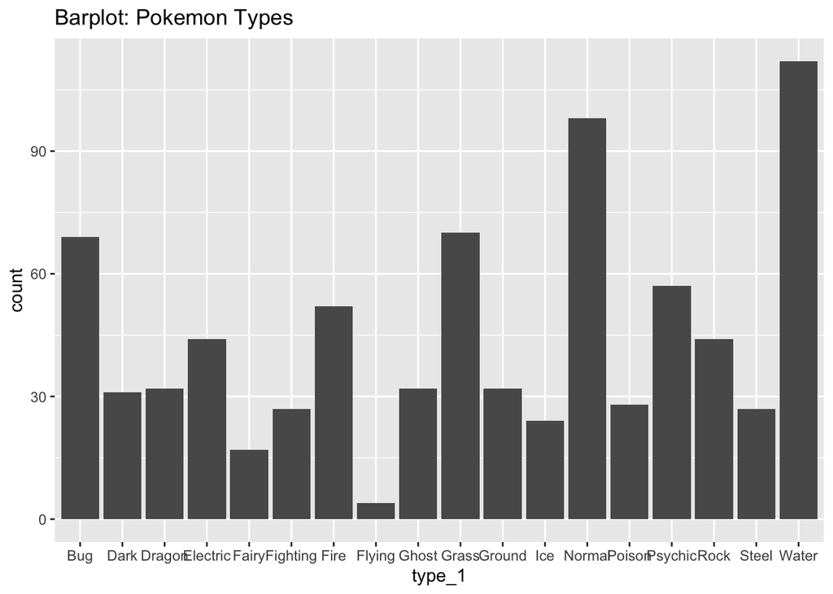

```r
ggplot(pokemon, aes(type_1)) +
  geom_bar() +
  labs(title= "Barplot: Pokemon Types")
```

18 classes of the outcome “type_1” – with relatively few Flying-type pokemon.

```r
pokemon %>% count(type_1)
```

```
## # A tibble: 18 × 2
##    type_1       n
##    <chr>    <int>
##  1 Bug         69
##  2 Dark        31
##  3 Dragon      32
##  4 Electric    44
##  5 Fairy       17
##  6 Fighting    27
##  7 Fire        52
##  8 Flying       4
##  9 Ghost       32
## 10 Grass       70
## 11 Ground      32
## 12 Ice         24
## 13 Normal      98
## 14 Poison      28
## 15 Psychic     57
## 16 Rock        44
## 17 Steel       27
## 18 Water      112
```

```r
dat <- pokemon %>%
  filter(type_1 %in% c("Bug", "Fire", "Grass", "Normal", "Water", "Psychic"))

dat <- dat %>%
  mutate(type_1 = as.factor(type_1)) %>%
  mutate(legendary = as.factor(legendary)) %>%
  mutate(generation = as.factor(generation))
```

### Exercise 3

```r
set.seed(24)
poke_split <- initial_split(dat, prop = 0.70, strata = type_1)
poke_train <- training(poke_split)
poke_test <- testing(poke_split)

dim(poke_train)
```

```
## [1] 318  13
```

```r
dim(poke_test)
```

```
## [1] 140  13
```

Stratifying the folds is useful because there are fewer of some types of pokemon than others, and because our data set (~458 obs) is not very large. We want each fold to have good variation in terms of type.

```r
poke_folds <- vfold_cv(poke_train, v = 5, strata = type_1)
poke_folds
```

```
## #  5-fold cross-validation using stratification
## # A tibble: 5 × 2
##   splits           id
##   <list>           <chr>
## 1 <split [252/66]> Fold1
## 2 <split [253/65]> Fold2
## 3 <split [253/65]> Fold3
## 4 <split [256/62]> Fold4
## 5 <split [258/60]> Fold5
```

### Exercise 4

```r
poke_recipe <- recipe(type_1 ~ legendary + generation + sp_atk + attack + speed + defense + hp + sp_def, data = poke_train) %>%
  step_dummy(legendary) %>%
  step_dummy(generation) %>%
  step_normalize(all_predictors())
```

### Exercise 5

```r
elastic_net_spec <-
  multinom_reg(penalty = tune(), mixture = tune()) %>%
  set_mode("classification") %>%
  set_engine("glmnet")

elastic_net_workflow <- workflow() %>%
  add_recipe(poke_recipe) %>%
  add_model(elastic_net_spec)

param_grid <- grid_regular(penalty(range = c(-5, 5)),
                           mixture(range = c(0, 1)), levels = 10)
```

### Exercise 6

```r
tune_results <- tune_grid(
  elastic_net_workflow,
  resamples = poke_folds,
  grid = param_grid
)

tune_results
```

```
## # Tuning results
## # 5-fold cross-validation using stratification
## # A tibble: 5 × 4
##   splits           id    .metrics           .notes
##   <list>           <chr> <list>             <list>
## 1 <split [252/66]> Fold1 <tibble [200 × 6]> <tibble [0 × 3]>
## 2 <split [253/65]> Fold2 <tibble [200 × 6]> <tibble [0 × 3]>
## 3 <split [253/65]> Fold3 <tibble [200 × 6]> <tibble [0 × 3]>
## 4 <split [256/62]> Fold4 <tibble [200 × 6]> <tibble [0 × 3]>
## 5 <split [258/60]> Fold5 <tibble [200 × 6]> <tibble [0 × 3]>
```

Smaller amounts of regularization produce better accuracy and ROC AUC, with the different types of regularization producing similar results at these smaller values. When regularization increases via penalty, ridge models perform marginally better.

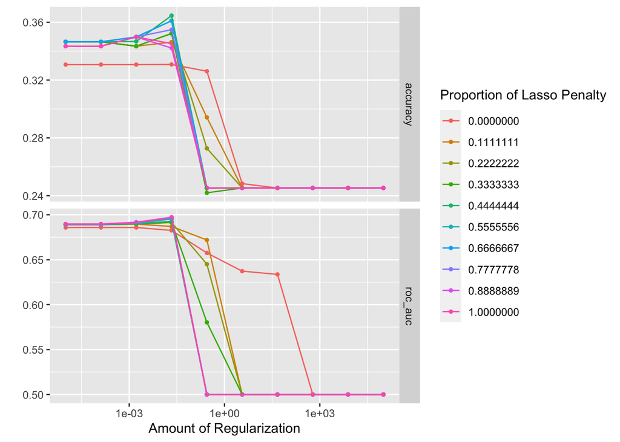

```r
autoplot(tune_results)
```

### Exercise 7

```r
best_param <- select_best(tune_results, metric = "accuracy")

elastic_net_final <- finalize_workflow(elastic_net_workflow, best_param)

elastic_net_final_fit <- fit(elastic_net_final, data = poke_train)

augment(elastic_net_final_fit, new_data = poke_test) %>%
  accuracy(truth = type_1, estimate = .pred_class)
```

```
## # A tibble: 1 × 3
##   .metric  .estimator .estimate
##   <chr>    <chr>          <dbl>
## 1 accuracy multiclass     0.307
```

### Exercise 8

Overall ROC AUC = 0.69

```r
augment(elastic_net_final_fit, new_data = poke_test) %>%
  roc_auc(type_1, estimate = c(.pred_Bug, .pred_Fire, .pred_Grass, .pred_Normal, .pred_Psychic, .pred_Water))
```

```
## # A tibble: 1 × 3
##   .metric .estimator .estimate
##   <chr>   <chr>          <dbl>
## 1 roc_auc hand_till      0.695
```

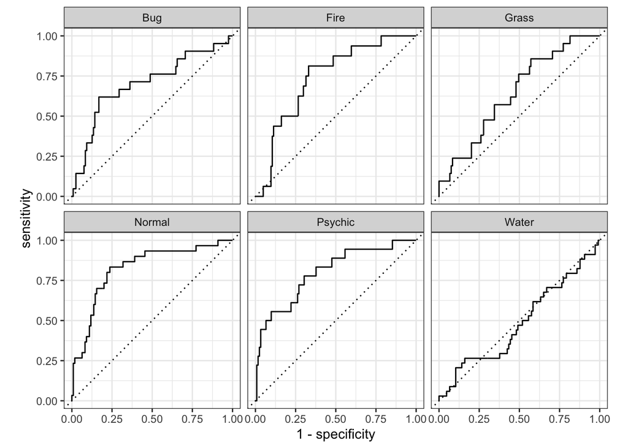

```r
augment(elastic_net_final_fit, new_data = poke_test) %>%
  roc_curve(type_1, estimate = c(.pred_Bug, .pred_Fire, .pred_Grass, .pred_Normal, .pred_Psychic, .pred_Water)) %>%
  autoplot()
```

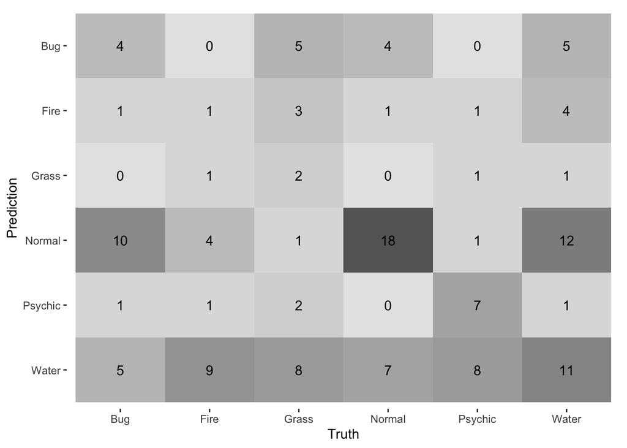

```r
augment(elastic_net_final_fit, new_data = poke_test) %>%
  conf_mat(truth = type_1, estimate = .pred_class) %>%
  autoplot(type = "heatmap")
```

The model is not great at predicting Pokemon types. It does best at predicting ‘Normal’ type pokemon and worst at predicting Water type pokemon. This might be because there are many ‘Normal’ type pokemon in the dataset. However, there are also many Water type pokemon. Hard to say.

## For 231 Students

### Exercise 9

In the 2020-2021 season, Stephen Curry, an NBA basketball player, made 337 out of 801 three point shot attempts (42.1%). Use bootstrap resampling on a sequence of 337 1’s (makes) and 464 0’s (misses). For each bootstrap sample, compute and save the sample mean (e.g. bootstrap FG% for the player). Use 1000 bootstrap samples to plot a histogram of those values. Compute the 99% bootstrap confidence interval for Stephen Curry’s “true” end-of-season FG% using the quantile function in R. Print the endpoints of this interval.

```r
set.seed(24)

curry <- data.frame(x=c(0,1))

curry <- curry %>%
  mutate(count = c(464, 337)) %>%
  uncount(count)

meanfun <- function(curry, i){
  d <- curry[i, ]
  return(mean(d))
}

boot_curry <- boot(curry, statistic=meanfun, R=1000)
boot.ci(boot_curry, conf=0.99, type="bca")
```

```
## BOOTSTRAP CONFIDENCE INTERVAL CALCULATIONS
## Based on 1000 bootstrap replicates
##
## CALL :
## boot.ci(boot.out = boot_curry, conf = 0.99, type = "bca")
##
## Intervals :
## Level       BCa
## 99%   ( 0.3786,  0.4697 )
## Calculations and Intervals on Original Scale
## Some BCa intervals may be unstable
```

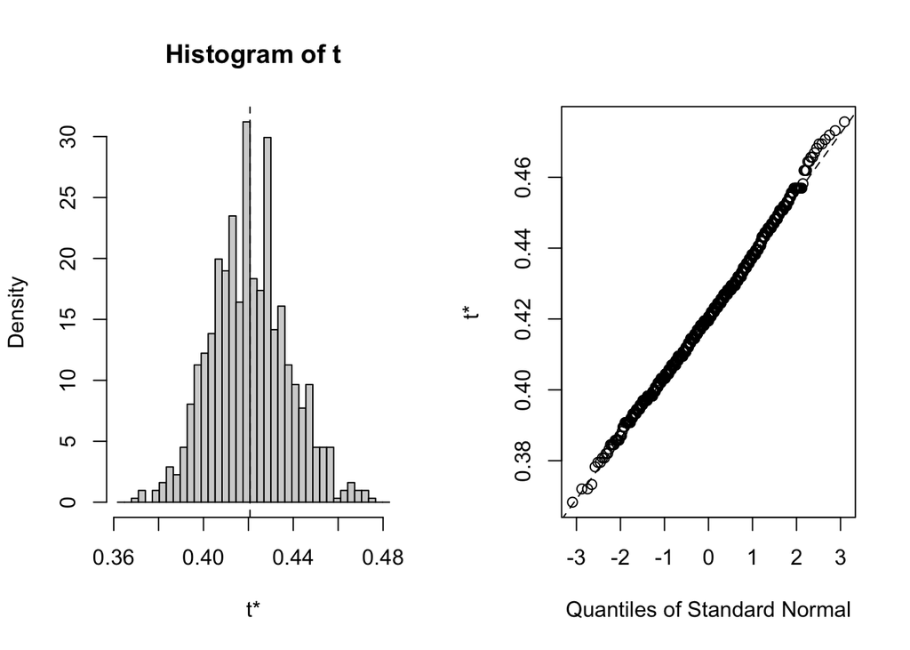

```r
plot(boot_curry)
```